# Praca domowa ze wstępu do uczenia maszynowego nr 1

Marceli Korbin

8 marca 2020

## Wstęp

W pracy domowej przyglądam się zbiorowi danych nt. kredytów w Niemczech (dostępnemu na stronie https://www.mldata.io/dataset-details/german_credit_data/). Dane znajdują się w pliku *german_credit_data_weka_dataset.csv*, a ich opis w dodatkowym pliku *attributes_german_credit_data.csv*, do którego w dalszej części pracy domowej będę odnosić się w ramach opisu zmiennych.

## Przyczyna wzięcia kredytu w zależności od zatrudnienia

### Opis zmiennych *purpose* i *present_employment*

```
## [1] "Purpose of Credit (A40 : car (new), A41 : car (used), A42 : furniture/equipment, A43 : radio/television, A44 : domestic appliances, A45 : repairs, A46 : education, A47 : (vacation - does not exist?), A48 : retraining, A49 : business, A410 : others)"
```

```
## [1] "A71 : unemployed, A72 : < 1 year, A73 : 1 <= x < 4 years, A74 : 4 <= x < 7 years, A75 : .. >= 7 years"
```

### Wykres

```r
rpivotTable(kredyty, cols = "present_employment", rows = "purpose", aggregatorName="Count", vals = "Value",
            rendererName = "Col Heatmap", height=800, subtotals=FALSE)
```

[interactive table not shown]

### Wnioski

Najczęściej klienci brali kredyt w celu kupna samochodu lub sprzętu RTV. Bezrobotni klienci stanowią jedyną grupę, w której radio i telewizja nie były najpopularniejszym celem skonsumowania kredytu; częściej zależało im na samochodzie lub umeblowaniu.

## Rozkład kredytu według długości pożyczki i wieku kredytobiorcy

### Opis zmiennych *duration* i *age*

```
## [1] "Duration in month"
```

```
## [1] "Age in years"
```

### Wykres

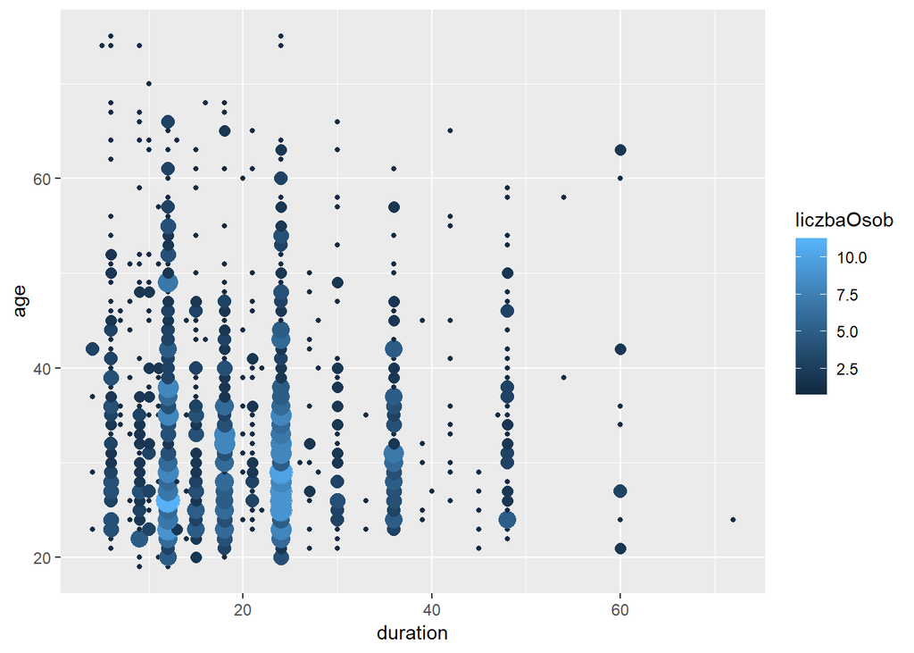

```r
age_dur <- kredyty %>% group_by(age, duration) %>% count()
colnames(age_dur) <- c("age", "duration", "liczbaOsob")

ggplot(age_dur, aes(x=duration, y=age)) + geom_point(aes(colour=liczbaOsob, size=liczbaOsob)) + guides(size=FALSE)
```

### Wnioski

Kredyt zazwyczaj był brany na rok lub 2 lata, przez ludzi w wieku do 40 lat.

## Wysokość kredytu względem historii kredytowej

### Opis zmiennej *credit_history*

```
## [1] "A30: no credits taken/ all credits paid back duly, A31: all credits at this bank paid back duly, A32: existing credits paid back duly till now, A33: delay in paying off in the past, A34 : critical account/ other credits existing (not at this bank)"
```

### Wykres

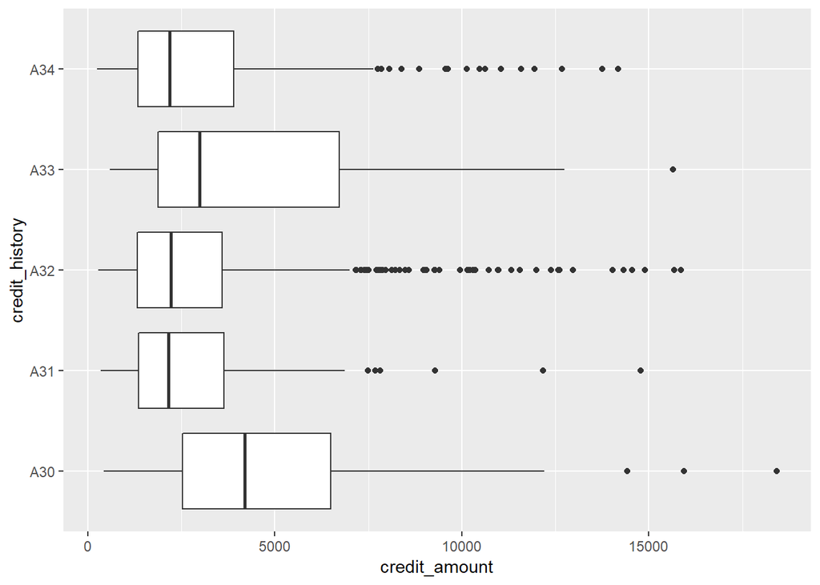

```r
ggplot(kredyty, aes(x=credit_history, y=credit_amount)) + geom_boxplot() + coord_flip()
```

### Wnioski

Z wyjątkiem dwóch grup, typowa wysokość kredytu wahała się w okolicach 2000 marek niemieckich. Większe wartości preferowali klienci biorący pierwszy kredyt lub nie spłacający na czas poprzednich kredytów z powrotem.

## Raport

Raport znajduje się w osobnym pliku pt. *report.html*. Nie udało mi się znaleźć sposobu na zamieszczenie jego treści wewnątrz tego dokumentu, co jestem skłonny zaliczyć jako ograniczenie narzędzia. Można ustawić elementy raportu (wykresy) oraz argumenty do przekazania do nich, ale trudno zmienić ich dane, szczególnie w wypadku wykresów analizy głównych składowych i korelacji.

Poniżej przebieg kompilacji.

```r
create_report(kredyty, config=configure_report(add_plot_prcomp = FALSE))
```

```
##
##
## processing file: report.rmd
```

[output not shown]

[output not shown]

[output not shown]

[output not shown]

[output not shown]

[output not shown]

[output not shown]

```
## output file: C:/Users/Marceli/Documents/2020L-WUM/Prace_domowe/Praca_domowa1/Grupa1/Korbin_Marceli/report.knit.md
```

[output not shown]

```
##
## Output created: report.html
```